# Pics or it Didn’t Happen? Assessing the Impact of Trail Photogenicity on Hiker Ratings in Washington

Aris Chalini, Ed Kirton, Rebecca Nissan

April 2022

# 1 Introduction

## 1.1 Motivation

What makes some hiking trails popular and others not? Is the trail choosing decision process simply a matter of assessing convenience and difficulty? All it takes is our intuition to know that there is more to it. When people choose hikes they are also deciding what they want to see. Nowadays in particular, we believe that people are interested in what pictures they will take. We think that for many people, taking an awesome picture during an endearing hike will have a positive effect on their likelihood to be fond of that particular hiking trail. This study seeks to test the effect of photogenic trail features on user generated trail ratings. Since not all hikers have access to all trails due to difficulty differences, we must control for difficulty. In general, we expect the effect of photogenicity on trail rating to be larger than that of trail difficulty.

Our hope is that findings from studies such as this one could be used to inform hiking trail design. This study is designed to guide our organization, the Washington Trails Association, in deciding where and how to construct hiking trails. We are interested in understanding which photogenic features appeal to Washington hikers and to what extent a hike’s photogeneity imapcts hiker ratings. We suspect that many people choose hikes that are most likely to produce content that would generate additional “likes” on Instagram or similar platforms. Therefore, the existence of photogenic features on a trail may lead to a higher average rating. If we learn that our identified set of photogenic features do lead to higher ratings, we might consider building more trails that highlight those particular features or incorporating signage that directs hikers towards photo opportunities.

## 1.2 Research Question

Given our data source and the methodology of our research, the research question we will be answering is the following:

**Do photogenic features cause trails to be rated more highly in Washington State?**

Our Y variable - trail ratings - is included in our primary data source and reflects the opinions of people who use the Washington Trails Association’s website to assess hikes. Our X variable, a feature we’ve called “photogenicity,” reflects the presence of one or more features that we consider to be photogenic. These features should make a hike more appealing for those wishing to post about it on social media websites. Thus, photogenicity is operationalized as a indicator variable based on the presence of any of the following four features: Mountains, Waterfalls, Lakes, and Summit Views. Our choice of which features to include was informed by a sub-study of popular instagram pictures, the methodology for which will be detailed in the a later section.

# 2 Data and Methology

## 2.1 About the Data

Our dataset is scraped from the Washington Trails Association’s website [WTA](https://www.wta.org/go-outside/hikes). It is a donation-funded organization that relies heavily on volunteers and corporate partners. They provide hiking guides, champion environmental stewardship, created Washington’s larges volunteer trail maintenance program, and collect useful trail information. Their website provides users (free to join) with a hiking guide that has a total of 3933 listings. Expert hikers write the content for each trail listing which is then vetted by WTA staff. Our scraping function was provided by TidyX and is slightly edited in order to scrape one additional piece of information: rating vote counts [tidytuesday](https://github.com/rfordatascience/tidytuesday/blob/master/data/2020/2020-11-24/readme.md).

## 2.2 Outcome Variable

Our outcome variable is the average rating for each trail. Each WTA user has the option to rate any trail listed on the site with a score from 1 to 5 stars. No partial stars are allowed when a user is assigning their rating to a trail. That is, any user has the following set of values to choose from when rating a video: [1, 2, 3, 4, 5]. However, the average rating does allow for partial stars based on a decimal rounded to the nearest hundredth. Since our outcome variable is an average, we have decided to omit records where the average does not correspond to at least 5 votes.

There are 1217 records in this dataset. On this rating scale, without any influential factors the expectation would be 3 stars. The mean rating for these 1217 records is 3.574 and the median rating is 3.620. The mean rating_count for this dataset is 17.45 votes and the median rating_count is 8.00 votes.

Ten observations of rating are flagged as outliers for being outside the Q1-1.5IQR standard for minimums. Despite these outliers, our distribution is relatively normal with only a slight left skew in the direction of those outliers. This slight skew could demonstrate a predisposition of WTA users to rate trails more fondly. Another possibility is that people who go through the trouble of going on a hike they found, are more likely to choose a hike which they would rate more fondly.

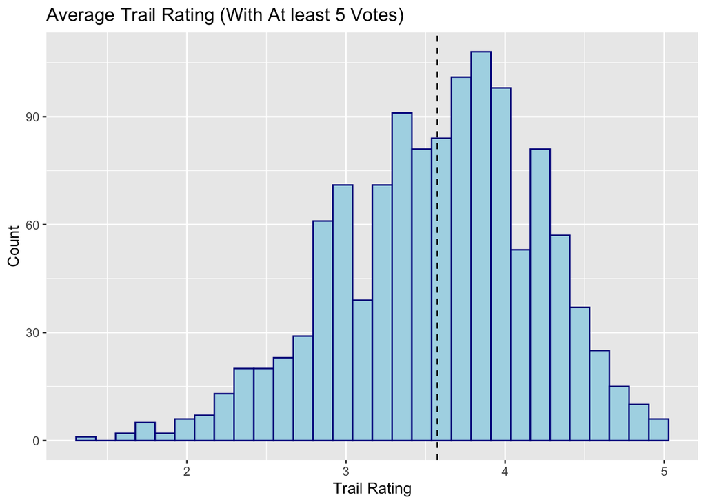

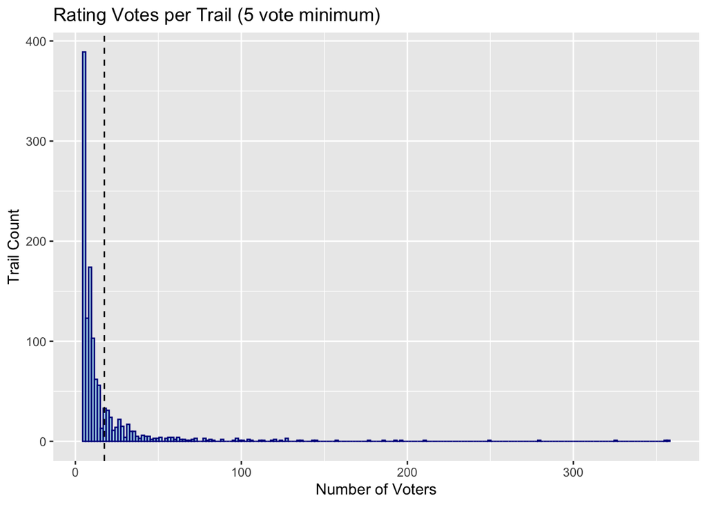

## 2.3 Trail Features

The trail feature strings were transformed into R features and a `loop` feature was added to indicate whether that keyword appeared in the trail description text.

### Operationalizing Trail Photogenicity

In order to inform our conception of trail photogenicity we examined instagram photos and tallied key features. We did this in two different ways: (1) we looked at 30 photos gathered from doing a search for “washington trails” and (2) we looked at 30 photos from the top tags related to hiking trails in Washington state. In both cases, every ninth photo was selected for the sample and the number of times each of the available features was observed. The CSV files may be found in this report’s Git repository. The most common four features are combined into a new boolean indicator: `photogenic`. The variable is True when a trail contains any of the most popular features found in Instagram’s recommended trail photos.

### Controls

The data retrieved from the WTA has length as a string, so in order to obtain numeric values, we needed to match for the descriptive words “one-way” and “roundtrip” and multiple by 2 or 1, respectively, in order to have comparable (roundtrip) values. The phrase “miles of trails” was also used, to describe a network of available trails and it seemed reasonable to use 0.5 as a multiplier in this case. The `total_miles` is the product of the numeric value and the multiplier; this value is used as the length in all analyses to follow.

The mean trail length is 9.14 miles and the median length is 7.000 miles. There are 76 outliers in this dataset. While the max value is 295 miles, 94% of the data has a value less than the minimum outlier (20.2 miles). This results in an extremely skewed distribution. Since we are only interested in trails that an average person can do in a day or a weekend, we felt these extremely long trails belonged to an exceptional set (“excursions”) and should be excluded. Removal of these outliers would lead to a more normal distribution. It is slightly skewed to the right with a mean trail length of 6.973 miles and a median trail length of 6.4 miles. Removal of these outliers results in in a distribution where the mean and median are much closer in value. Hereafter we consider only trails that are at most 20 miles in length.

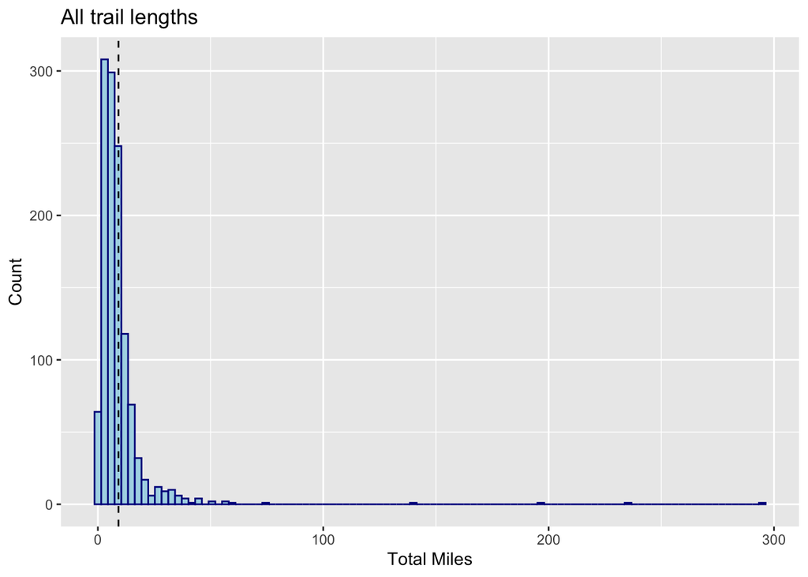

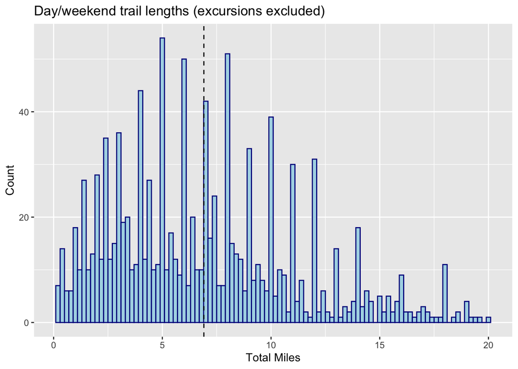

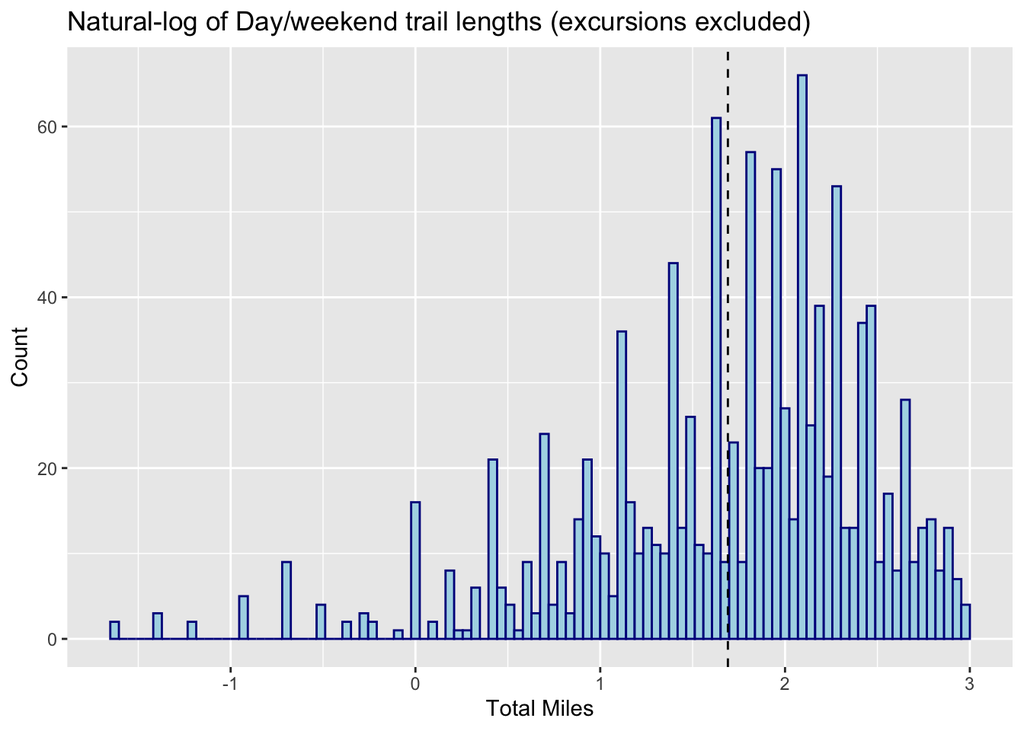

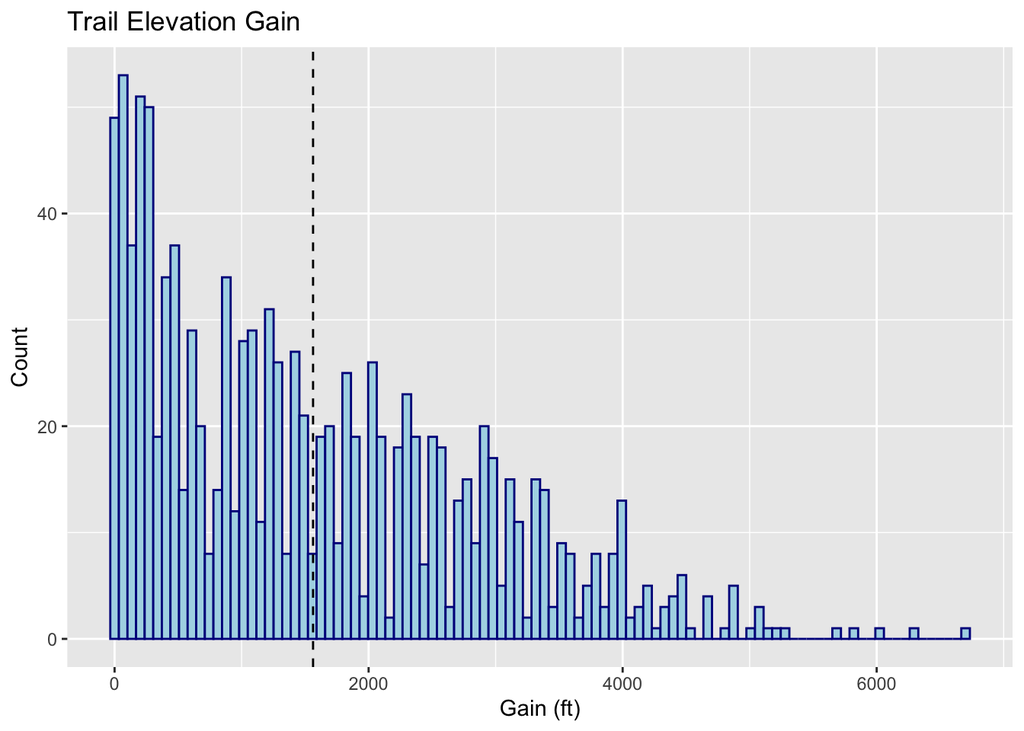

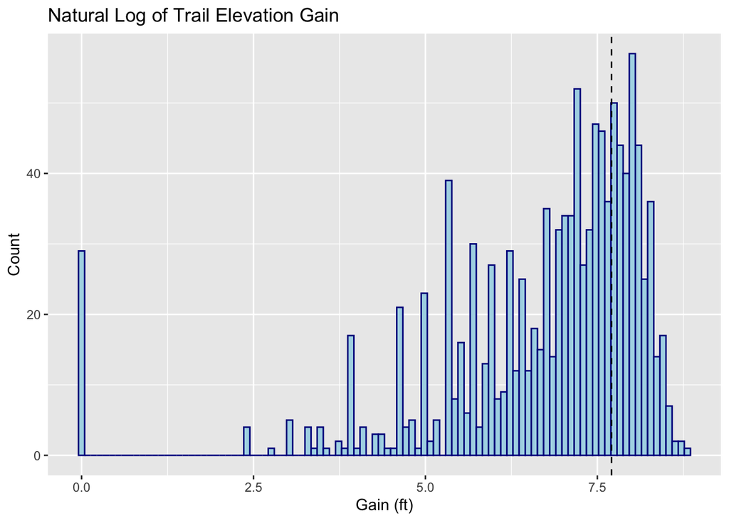

We decided to use the untransformed total length and gain as the log-transformed histograms did not appear better (e.g. more bell-shaped).

The difficulty of a trail is largely determined by both it’s total length and elevation change. These distances are combined into a `difficulty` score by scaling their measurements by using the proportion to the maximums and taking their product.

## 2.4 Breakdown by Environment

Hikes vary considerably by their environment. To determine whether our analysis holds in every environment, we’ve classified hikes as belonging to one of three environment types based upon their location.

# 3. Modeling

In order to assess the effect of photogenicity on trail ratings, we first explore a basic model, and then build subsequent models with additional covariates to potentially improve explanatory power.

Our first two models are as follows:

$$rating = \beta_0 + \beta_1 photogenic + \beta_2 difficulty$$

$$rating = \beta_0 + \beta_1 photogenic + \beta_2 total_miles + \beta_3
gain$$
Even our most basic model includes a control for hike difficulty because we deem it so important that it should not be excluded. Our initial (a priori) hypothesis was that photogenicity partially determines ratings.

Here we check whether combining total miles and elevation gain into difficulty is better than having them apart.

```
##
## t test of coefficients:
##
##                 Estimate Std. Error t value  Pr(>|t|)
## (Intercept)    3.3673795  0.0498266 67.5820 < 2.2e-16 ***
## photogenicTRUE 0.2435055  0.0495706  4.9123 1.032e-06 ***
## difficulty     0.0099974  0.0507739  0.1969    0.8439
## ---
## Signif. codes:  0 '***' 0.001 '**' 0.01 '*' 0.05 '.' 0.1 ' ' 1
```

```
##
## t test of coefficients:
##
##                   Estimate  Std. Error t value  Pr(>|t|)
## (Intercept)     3.4394e+00  5.2407e-02 65.6291 < 2.2e-16 ***
## photogenicTRUE  2.0258e-01  5.0016e-02  4.0502 5.464e-05 ***
## total_miles    -2.5181e-02  6.1442e-03 -4.0983 4.457e-05 ***
## gain            9.0469e-05  1.9782e-05  4.5733 5.327e-06 ***
## ---
## Signif. codes:  0 '***' 0.001 '**' 0.01 '*' 0.05 '.' 0.1 ' ' 1
```

|  | Res.Df | RSS | Df | Sum of Sq | F | Pr(>F) |
| --- | --- | --- | --- | --- | --- | --- |
| 1 | 1139 | 433.1756 | NA | NA | NA | NA |
| 2 | 1138 | 424.6397 | 1 | 8.535937 | 22.87562 | 1.954958e-06 |

From above, we see that we should not combine total miles and gain into a single variable.

We also (a priori) expected trails with the “loop” keyword in the description to be a determining factor.

$$rating = \beta_0 + \beta_1 photogenic + \beta_2 total_miles + \beta_3
gain + \beta_4 loop$$

However, an F-test did not support our expectation and the “loop” feature was not included in subsequent models.

```
##
## t test of coefficients:
##
##                   Estimate  Std. Error t value  Pr(>|t|)
## (Intercept)     3.4450e+00  5.3464e-02 64.4360 < 2.2e-16 ***
## photogenicTRUE  2.0178e-01  5.0043e-02  4.0321 5.897e-05 ***
## total_miles    -2.5369e-02  6.1741e-03 -4.1089 4.261e-05 ***
## gain            8.9956e-05  1.9859e-05  4.5297 6.530e-06 ***
## loopTRUE       -2.6301e-02  6.4615e-02 -0.4070    0.6841
## ---
## Signif. codes:  0 '***' 0.001 '**' 0.01 '*' 0.05 '.' 0.1 ' ' 1
```

|  | Res.Df | RSS | Df | Sum of Sq | F | Pr(>F) |
| --- | --- | --- | --- | --- | --- | --- |
| 1 | 1138 | 424.6397 | NA | NA | NA | NA |
| 2 | 1137 | 424.5650 | 1 | 0.07466341 | 0.1999512 | 0.6548454 |

Our dataset included other features that could also affect ratings. We tried adding all features not previously used to see if any of them might improve the model. (See stargazer table in Results for list of covariates.)

$$rating = \beta_0 + \beta_1 photogenic + \beta_2 total_miles + \beta_3
gain + \beta_4 kids + \beta_5 dogs + \beta_6 wildlife + \beta_7 autumn +
\beta_8 ridges + \beta_9 campsites + \beta_10 trees + \beta_11 flowers +
\beta_12 rivers + \beta_13 coast$$

```
##
## t test of coefficients:
##
##                   Estimate  Std. Error t value  Pr(>|t|)
## (Intercept)     3.2385e+00  7.0978e-02 45.6267 < 2.2e-16 ***
## photogenicTRUE  1.9757e-01  5.1019e-02  3.8724 0.0001140 ***
## total_miles    -2.8196e-02  6.6217e-03 -4.2580 2.234e-05 ***
## gain            1.3392e-04  2.2869e-05  5.8559 6.215e-09 ***
## kidsTRUE        1.9338e-01  4.4935e-02  4.3036 1.826e-05 ***
## dogsTRUE       -1.0908e-02  3.8020e-02 -0.2869 0.7742356
## wildlifeTRUE   -1.7758e-02  3.9276e-02 -0.4521 0.6512658
## autumnTRUE      4.8567e-02  4.2881e-02  1.1326 0.2576230
## ridgesTRUE      9.2467e-02  4.5605e-02  2.0276 0.0428405 *
## campsitesTRUE   1.0279e-01  4.3935e-02  2.3396 0.0194786 *
## treesTRUE      -1.6539e-02  3.9932e-02 -0.4142 0.6788320
## flowersTRUE     2.9303e-02  3.8405e-02  0.7630 0.4456204
## riversTRUE      2.1637e-02  4.0753e-02  0.5309 0.5955772
## coastTRUE       2.7670e-01  7.1078e-02  3.8929 0.0001049 ***
## ---
## Signif. codes:  0 '***' 0.001 '**' 0.01 '*' 0.05 '.' 0.1 ' ' 1
```

|  | Res.Df | RSS | Df | Sum of Sq | F | Pr(>F) |
| --- | --- | --- | --- | --- | --- | --- |
| 1 | 1138 | 424.6397 | NA | NA | NA | NA |
| 2 | 1128 | 407.6238 | 10 | 17.01583 | 4.708718 | 1.268728e-06 |

## 3b. Testing the model in different environments

Lastly we wished to see if our model holds up under each of the three environments.

```
Results by Region
======================================================================================
                                           Dependent variable:
                    ------------------------------------------------------------------
                                              Trail Ratings
                          Desert                Coastal              Mountainous
                            (1)                   (2)                    (3)
--------------------------------------------------------------------------------------
photogenic            -0.739 (0.536)       0.230*** (0.066)        0.205*** (0.078)
total_miles            0.002 (0.062)       -0.038*** (0.008)        0.001 (0.012)
gain                 -0.0001 (0.0002)     0.0002*** (0.00003)     0.00001 (0.00005)
kids                  0.740* (0.363)       0.231*** (0.055)         -0.009 (0.091)
dogs                   0.535 (0.458)         0.001 (0.045)          0.049 (0.073)
wildlife              -0.481 (0.308)        -0.003 (0.048)          -0.006 (0.070)
autumn                 0.439 (0.327)         0.041 (0.053)          0.011 (0.078)
ridges                0.547* (0.286)         0.076 (0.051)          0.137 (0.109)
campsites             0.568* (0.324)        0.105* (0.055)          0.091 (0.087)
trees                 -0.221 (0.292)        -0.054 (0.050)          0.087 (0.072)
flowers                0.012 (0.341)         0.027 (0.047)          0.045 (0.072)
rivers                -0.271 (0.296)         0.027 (0.052)          0.012 (0.076)
coast                                                              0.268*** (0.089)
Constant             3.330*** (0.393)      3.204*** (0.082)        3.267*** (0.130)
--------------------------------------------------------------------------------------
Observations                29                    826                    287
R2                         0.518                 0.100                  0.079
Adjusted R2                0.156                 0.087                  0.035
Residual Std. Error   0.560 (df = 16)      0.616 (df = 813)        0.550 (df = 273)
F Statistic         1.432 (df = 12; 16) 7.520*** (df = 12; 813) 1.801** (df = 13; 273)
======================================================================================
Note:                                                      *p<0.1; **p<0.05; ***p<0.01
```

# 4. Results

```
Results
==============================================================================================
                                               Dependent variable:
                    --------------------------------------------------------------------------
                                                  Trail Ratings
                              (1)                      (2)                      (3)
----------------------------------------------------------------------------------------------
photogenic              0.203*** (0.049)         0.202*** (0.049)         0.198*** (0.050)
total_miles            -0.025*** (0.006)        -0.025*** (0.006)        -0.028*** (0.006)
gain                  0.0001*** (0.00002)      0.0001*** (0.00002)      0.0001*** (0.00002)
loop                                              -0.026 (0.059)
kids                                                                      0.193*** (0.046)
dogs                                                                       -0.011 (0.037)
wildlife                                                                   -0.018 (0.039)
autumn                                                                     0.049 (0.043)
ridges                                                                    0.092** (0.045)
campsites                                                                 0.103** (0.046)
trees                                                                      -0.017 (0.040)
flowers                                                                    0.029 (0.039)
rivers                                                                     0.022 (0.042)
coast                                                                     0.277*** (0.080)
Constant                3.439*** (0.050)         3.445*** (0.051)         3.238*** (0.067)
----------------------------------------------------------------------------------------------
Observations                 1,142                    1,142                    1,142
R2                           0.042                    0.042                    0.081
Adjusted R2                  0.040                    0.039                    0.070
Residual Std. Error    0.611 (df = 1138)        0.611 (df = 1137)        0.601 (df = 1128)
F Statistic         16.692*** (df = 3; 1138) 12.560*** (df = 4; 1137) 7.600*** (df = 13; 1128)
==============================================================================================
Note:                                                              *p<0.1; **p<0.05; ***p<0.01
```

These results suggest that photogenic features do cause higher ratings by a small but significant amount. This is effect is robust to covariates, and represents about an effect size of about 0.2 points. In other words, on average, photogenic hikes receive 0.2 more points (on the 5-point scale) relative to non-photogenic hikes. This effect is statistically significant (p<0.01). We believe that this effect represents a meaningful but small practical significance. This change is only about 4% of the highest possible score (5), but it could be the difference between a 3.9 and a 4.1, which could feel very different to a prospective hiker. We also see statistically significant and positive effects for kid-friendly hikes and hikes with ridges, campsites, and coasts. Total miles has a small negative influence and gain has a statistically significant miniscule effect.

Follow-up analyses also showed that these findings only hold in two individual sub-regions (coastal and mountainous) but that is likely because we only have 29 observations for the desert, and also there are unlikely to be waterfalls or lakes in that area.

# 5. Limitations

## 5a. Statistical limitations

Since we have a large sample, we only need to evaluate the two large sample assumptions.

### Independent and Identically Distributed (I.I.D)

The I.I.D. assumption may be violated. A user can rate multiple trails, which could lead to some dependent relationship between those ratings consistent with that particular user’s preferences. Perhaps one very active user really likes steeper trails, and gives higher grades to all steep trails, thus driving up those ratings systematically. Similarly, the distribution of ratings from one user might differ from the distribution of ratings from another user if one is a more generous grader and the other is more harsh. In a future study, we might be able to control for this if we had information about which users provided which ratings.

Another potential violation of I.I.D comes from geographic clustering. Washington has multiple different environments, including the desert, several mountainous regions, and a coastal region. It is likely that observing one observation from a specific region would tell us something about other observations from that region. To mitigate this problem, we also examine our main model within each individual region.

## 5b. Structural Limitations

### Omitted Variable Bias

Despite our inclusion of several control variables (for example, the difficulty of the hike and other non-photogenic features), there are still several omitted variables that could affect both photogenicity and ratings:

*Season & Weather* The time of year when someone does a hike could definitely affect the rating - the same trail could be gorgeous in the summer and impassable in winter! The same is true about the weather on any given day. Season and weather also affect the existence of certain features such as waterfalls - or at least the ability to see and record those features. To take an example, you can say that early summertime causes higher ratings and “causes” waterfalls. If we do not account for the season in which ratings were recorded and the weather on the day of recording, we cannot determine if the photogenic features are really the thing driving ratings up, or if perhaps the driving factor is the season/weather.

*Accessibility* It is possible that people give higher ratings to trails that are close to a major city (or perhaps the opposite - maybe people like solitude). In either case, the ease of access to a trail can affect its rating. Trails that are accessible from developed areas may also be less likely to have superb mountain views or other key features.

### Reverse Causality

The risk of reverse causality is relatively low in this case because the existence or non-existence of features could not be changed by people’s opinions of those features. The only risk that arises here is that the tagging of those features is somehow biased by people’s preferences (for example, they only document the existence of a waterfall on the trail if they also liked the hike). In our dataset, this risk is low because experts build the hike profiles, and especially since they are not necessarily the same people casting the votes, it is reasonable to assume they are documenting features with fidelity.

### Potential Operationalization Issues

Perhaps the most notable limitation for our conclusions from this study is the fact that we don’t know whether the *reason* people rate trails with photogenic features highly is because they want to take good pictures on hikes - perhaps (we hope) people like to experience those features in the moment, and that’s why those features cause high ratings. If we wanted to further dissect the motivation behind trail preferences, we would need an experimental design.

# 6. Conclusion

The goal of this study was to evaluate the impact of key trail features on trail rating. In particular, we set out to see if the presence of photogenic features (i.e. Mountains, Waterfalls, Lakes, or a Summit Views) causes higher trail ratings. We found that when difficulty (total miles and gain) is held constant, the presence of any of these features is likely to cause a 0.2 increase in trail rating. The effect of trail photogenicity was found to be statistically significant, however it isn’t the only significant determinant.

We then created a second model that includes loop as a feature that may predict trail rating. Contrary to our a priori expectation, loop was found to not have a significant effect. In the interest of identifying significant features, a full model was run with all the relevant information available in the dataset and the t-test scores evaluated. We found that of remaining trail features, ridges, coasts, campsites, and kid-friendliness were also significant features.

By understanding what leads people to assign a high rating to a trail we can have a more informed approach to trail-building and trail-marketing.

However, we should note that our model didn’t find support for photogenic features in desert environments. This may be because of our operational definition, the small number of desert trails, and/or that people go to the desert for other features that we don’t have data for (e.g. solitude).